# Instability of Large Gene Network

Longxiao

In this R Notebook, we are going to show the fact that a large random matrix is less probable to be stable, in the sense of a dynamics system. We use a very simplified Wagner model of gene regulatory dynamic as an example.

# Simplified Model

We consider a very simplified linear difference equation model:
$$s_{i}(t+1) = \sum w_{ij} s_{j}(t)$$

where $s_i(t)$ is the expression level of gene $i$ at time $t$, $w_{ij}$ is the regulatory strength of gene $j$ on gene $i$. To better understand the system, we could also write the model in a matrix form:

$$\mathbf{s}_{t+1} = \mathbf{W} \cdot \mathbf{s}_{t}$$

where $\mathbf{s}_{t}$ is the vector of all gene expression value at time $t$, $\mathbf{W}$ is the regulatory matrix.

# Stable Condition

Assume there is a fixed point $\mathbf{s}^*$, such that $\mathbf{s}^* = \mathbf{W} \cdot \mathbf{s}^*$. This fixed point is an equilibrium of the system. To examine whether this equilibrium is stable or not, we define a disturb $\mathbf{u}(t) = \mathbf{s}_t - \mathbf{s}^*$ around it. Then we have:

$$\mathbf{s}(t+1) - \mathbf{s}^* = \mathbf{W} \cdot \mathbf{s}(t) -
\mathbf{W} \cdot \mathbf{s}^* \\
\mathbf{u}(t+1) = \mathbf{W} \cdot \mathbf{u}(t)$$

As a result,

$$\mathbf{u}(t) = \mathbf{W}^{t} \cdot \mathbf{u}(0)$$

where $\mathbf{u}_{0}$ is the initial disturb. If $\mathbf{s}^*$ is a stable equilibrium, it should attract nearby state. That is, any small disturb away from $\mathbf{s}^*$ should come back to it. This condition requires $\lim_{t \rightarrow\infty} \mathbf{u}(t) = 0$, which is met when $\lim_{t \rightarrow\infty} \mathbf{W}^{t} = 0$.

# Stability of Random Matrix

Based on the stable condition above, we examine the distribution of eigenvalues of random matrices. The elements of random matrix are set to follow the same normalized normal distribution:

$$M = \{ m_{ij} \}, m_{ij} \sim \mathcal{N}(0,1)$$

We firstly generate a 20 by 20 matrix as an example:

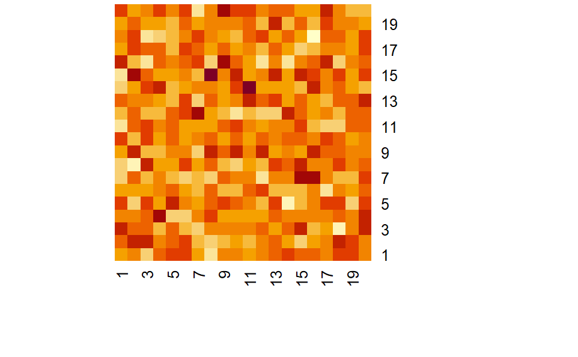

```r
random_matrix <- function(size,
                          dist_fun = rnorm, ...,
                          symmetric = FALSE){
  mat <- matrix(dist_fun(size * size, ...),
                nrow = size,
                ncol = size)

  if (symmetric) {
    mat <- (mat + t(mat)) / 2
  }

  return(mat)
}

mat <- random_matrix(20)
heatmap(mat,Rowv = NA, Colv = NA, scale = "none")
```

## Circular Law

We then examine the distribution of the eigenvalues. The eigenvalues of a random real-valued matrix are also solutions of a large linear function, as a result, they are complex numbers. We plot the eigenvalues in the complex plane.

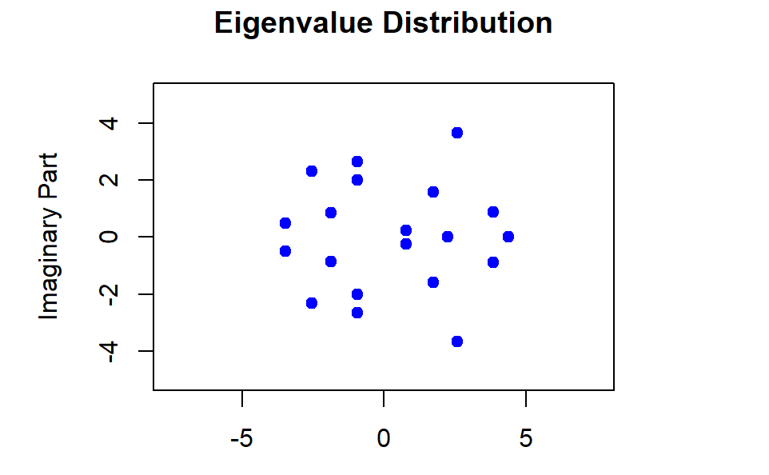

```r
# mat <- random_matrix(20)
par(pin = c(3,2))
plot(
  NA, NA,
  xlim = c(-5,5), ylim = c(-5, 5),
  xlab = "Real Part", ylab = "Imaginary Part",
  main = "Eigenvalue Distribution",
  asp = 1
)

points(eigen(mat)$values, pch = 19, col = "blue")
```

Then we could check the stability by compare the mod of eigenvalues with $1$.

```r
check_eigenvalues<- function(mat) {

  eigenvalues <- eigen(mat)$values

  return(all(Mod(eigenvalues) < 1))
}
check_eigenvalues(mat)
```

```
[1] FALSE
```

Obviously, most of the eigenvalues are large then $1$. We could notice that all the eigenvalues seems to distribute in a circle. The distribution of the eigenvalues of a matrix is the so called **Spectrum** of the mtrix. And here is a circular law of random matrix: if the elements of a $n$ by $n$ random matrix follow the same symmetrical distribution with mean 0 and variance 1, with the increase of $n$, the distribution of eigenvalues $\lambda_i$ divided by $\sqrt{n}$ converge to a uniform distribution in the united circle. That is, the radius of the spectrum converge to $\sqrt{n}$.

$$\lim_{n \rightarrow \infty} r = \sqrt{n}$$

We could show this with random matrices of different size.

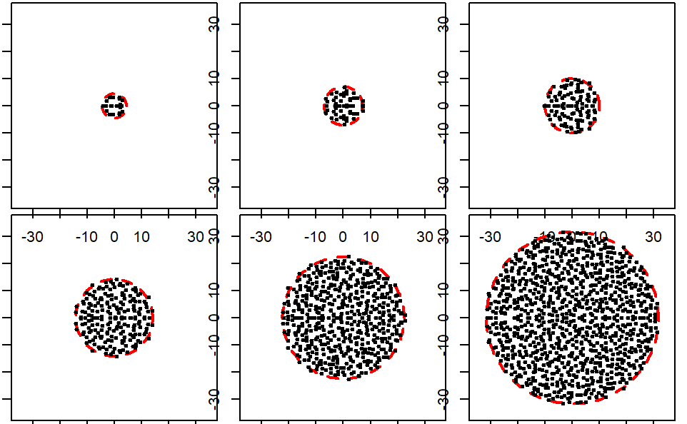

```r
size<-c(20,50,100,200,500,1000)

par(pin = c(1.5,1.5), mfrow = c(2,3))

for (i in size) {
  mati <- random_matrix(i)

  rad <- sqrt(i)
  theta <- seq(0, 2*pi, length.out = 200)
  circle_x <- rad*cos(theta)
  circle_y <- rad*sin(theta)

  #plot_scale = 1.2 * rad
  plot_scale = 35

  plot(
    NA, NA,
    xlim = c(-plot_scale,plot_scale),
    ylim = c(-plot_scale, plot_scale),
    xlab = "Re", ylab = "Im",
    main = paste("n = ", i),
    asp = 1
    )

  lines(circle_x, circle_y, col = "red", lty = 2, lwd = 2)

  points(eigen(mati)$values, pch = 19, col = "black", cex = 0.5)
}
```

We add the spectral radius circle as well as a circle of which the radius is $1$ to show the stable criteria to the size $20$ matrix.

```r
#mat <- random_matrix(20)
rad <- sqrt(20)
rad_i <- 1
theta <- seq(0, 2*pi, length.out = 200)
circle_x <- rad*cos(theta)
circle_y <- rad*sin(theta)
circle_ix <- rad_i*cos(theta)
circle_iy <- rad_i*sin(theta)

par(pin = c(3,2))
plot(
  NA, NA,
  xlim = c(-5,5), ylim = c(-5, 5),
  xlab = "Real Part", ylab = "Imaginary Part",
  main = "Eigenvalue Distribution",
  asp = 1
)

lines(circle_x, circle_y, col = "gray", lty = 2, lwd = 2)
```

[figure not shown]

```r
lines(circle_ix, circle_iy, col = "red", lty = 2, lwd = 2)

points(eigen(mat)$values, pch = 19, col = "black")
```

To show the eigenvalue distribution more clearly, we add eigenvalues of $1000$ random matrices of size $20$. We also count how many eigenvalues are real value.

```r
n<-20
m<-1000

real_eigen<-rep(0,m)

rad <- sqrt(n)
rad_i <- 1
theta <- seq(0, 2*pi, length.out = 200)
circle_x <- rad*cos(theta)
circle_y <- rad*sin(theta)
circle_ix <- rad_i*cos(theta)
circle_iy <- rad_i*sin(theta)

par(pin = c(4,3))
plot(
  NA, NA,
  xlim = c(-5, 5), ylim = c(-5, 5),
  xlab = "Real Part", ylab = "Imaginary Part",
  #main = "Eigenvalue Distribution",
  asp = 1
)

for (i in 1:m) {
  mati<- random_matrix(n)

  # if(prod(Mod(eigen(mat)$values)<=1)){
  #   points(eigen(mat)$values, pch = 19, col = "red", cex = 0.5)
  # }
  real_eigen[i] <- sum(Im(eigen(mati)$values)==0)
  points(eigen(mati)$values, pch = 19, col = rgb(0.5,0.5,0.5,0.1), cex = 0.5)
}
```

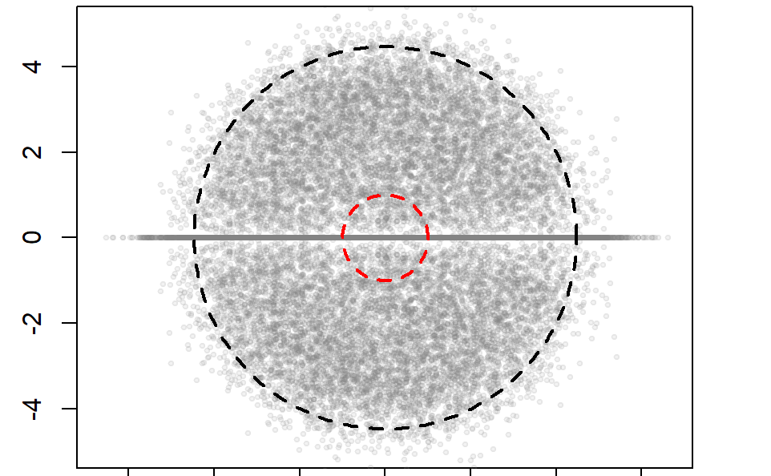

```r
lines(circle_x, circle_y, col = "black", lty = 2, lwd = 2)
lines(circle_ix, circle_iy, col = "red", lty = 2, lwd = 2)
```

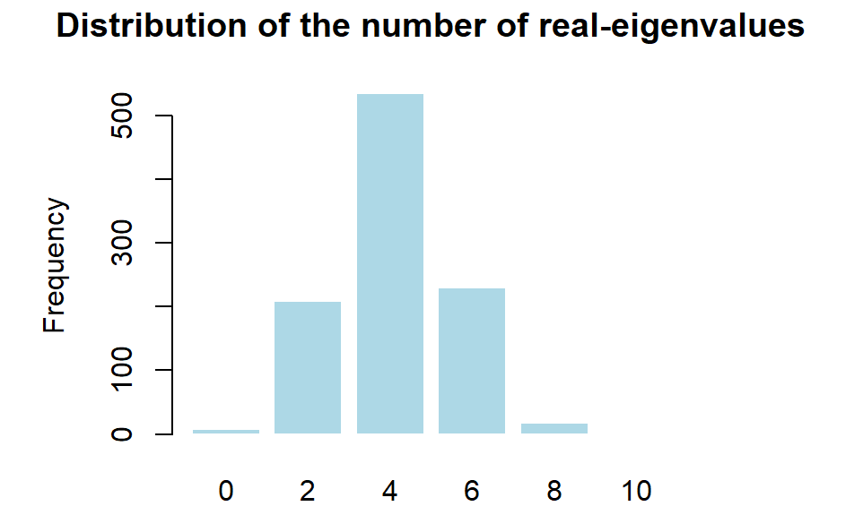

```r
real_num_freq<-table(real_eigen)
par(pin = c(3,2))
barplot(real_num_freq,
     main = "Distribution of the number of real-eigenvalues",
     xlab = "number of real-eigenvalues",
     ylab = "Frequency",
     col = "lightblue",
     border = "white")
```

## Change the Spectral Radius

The spectral radius is actually related to the mean strength (the value of elements). As a result, the radius will change if we change the mean strength, by decrease the variance, or decrease the elements density.

If the variance of elements is $\mathbf{E} M^2_{ij} = \sigma^2$, the radius will follows:

$$\lim_{n \rightarrow \infty} r = \sigma \cdot \sqrt{n}$$
We could assume that when $k \leq 1/n$, the mod of eigenvalues are probable less then 1, making the system stable. We check the stability of random matrix (size $20$) with different variance.

```r
size = 20
str_var <- seq(0.01, 0.1, by = 0.005)
stable_probs_k <- numeric(length(str_var))
total <- 10000

for (i in seq_along(str_var)) {
  k <- str_var[i]
  count <- 0
  for (j in 1:total) {
    mati<- random_matrix(size, sd = sqrt(k))

    if (check_eigenvalues(mati)) {
      count <- count + 1
    }
  }

  stable_probs_k[i] <- count/total
}
```

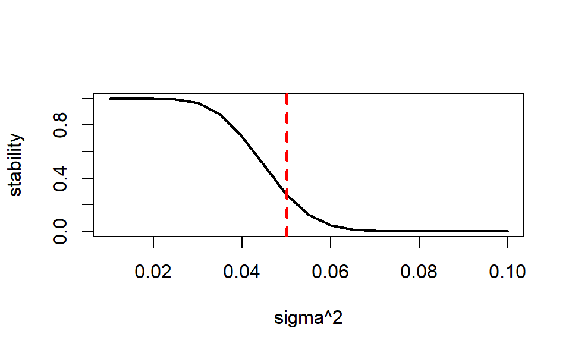

```r
plot(str_var, stable_probs_k, type = "l", lwd = 2,
     xlab = "sigma^2", ylab = "stability",)
abline(v = 1/20, col = "red",lwd = 2, lty = 2)
```

Th red line is $k = \frac{1}{n} = 0.05$, which could be viewed as the stable threshold.

Beside, if we set the density of non-zero elements in a matrix is $C$ (which means the connectedness of the network), the radius will follow:

$$\lim_{n \rightarrow \infty} r = \sqrt{C \cdot n}$$

For example, we generate a sparse matrix.

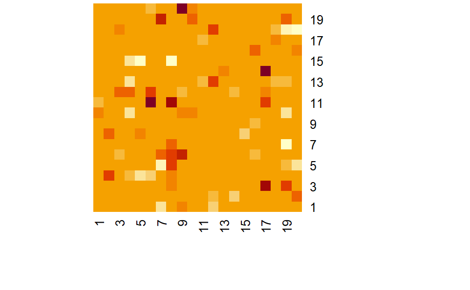

```r
sparse_matrix <- function(size,
                          density = 0.2,
                          dist_fun = rnorm, ...,
                          symmetric = FALSE){
  total <- size*size
  target_nonzero <- round(total * density)

  mat <- matrix(0, size, size)
  idx <- sample(total, target_nonzero)
  mat[idx] <- dist_fun(target_nonzero, ...)
  if (symmetric) mat <- (mat + t(mat)) / 2

  return(mat)
}

sparse_mat <- sparse_matrix(20)
heatmap(sparse_mat,Rowv = NA, Colv = NA, scale = "none")
```

The eigenvalue distributed in a smaller circle

```r
#sparse_mat <- sparse_matrix(20)
rad <- sqrt(20)
rad_c <- sqrt(20*0.2)
theta <- seq(0, 2*pi, length.out = 200)
circle_x <- rad*cos(theta)
circle_y <- rad*sin(theta)
circle_cx <- rad_c*cos(theta)
circle_cy <- rad_c*sin(theta)

par(pin = c(3,2))
plot(
  NA, NA,
  xlim = c(-5,5), ylim = c(-5, 5),
  xlab = "Real Part", ylab = "Imaginary Part",
  main = "Eigenvalue Distribution",
  asp = 1
)

lines(circle_x, circle_y, col = "gray", lty = 2, lwd = 2)
```

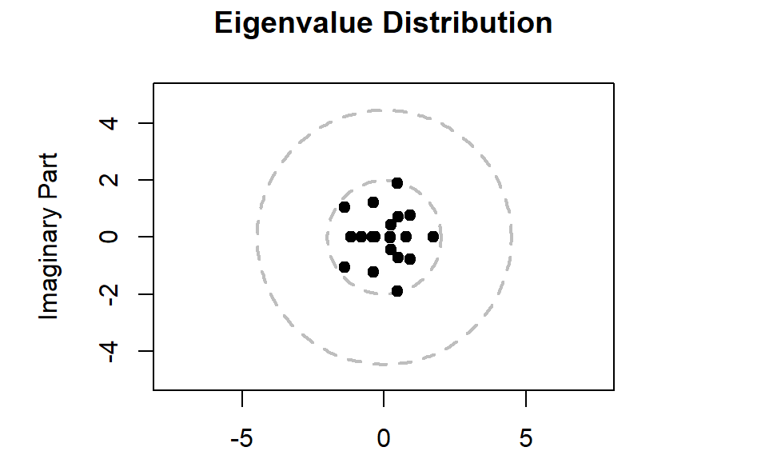

```r
lines(circle_cx, circle_cy, col = "gray", lty = 2, lwd = 2)

points(eigen(sparse_mat)$values, pch = 19, col = "black")
```

Similarly, we check the stability of random matrices with different density.

```r
densities <- seq(0.01, 0.2, by = 0.01)
stable_probs_c <- numeric(length(densities))
total <- 10000

for (i in seq_along(densities)) {
  density <- densities[i]
  count <- 0

  for (j in 1:total) {
    mati <- sparse_matrix(20, density)

    if (check_eigenvalues(mati)) {
      count <- count + 1
    }
  }

  stable_probs_c[i] <- count/total
}
```

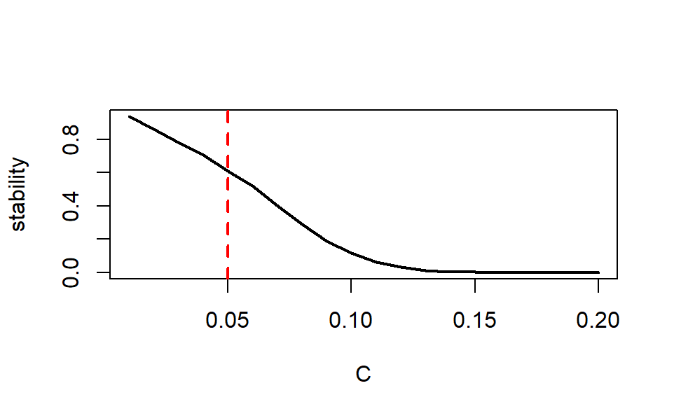

```r
plot(densities, stable_probs_c, type = "l", lwd = 2,
     xlab = "C", ylab = "stability")
abline(v = 1/20, col = "red",lwd = 2, lty = 2)
```

Also the red line is $C = \frac{1}{n} = 0.05$.

The general condition is

$$\lim_{n \rightarrow \infty} r = \sigma \cdot \sqrt{C \cdot n}$$

# Nestedness and Modularity

A lot of studies have shown that some structures could increase the stability of matrices. The most important two statistics are nestedness and modularity. Here we generated several perfectly nested and module matrices, and show the stability difference with sparse matrix (to control the density) under different variance.

Both of the statistics are defined on binary matrix.

```r
# Function: Binarize matrix by absolute threshold
binarize_matrix <- function(mat, threshold = 0.001) {
  if (!is.matrix(mat)) stop("Input must be a matrix.")
  binary_mat <- ifelse(abs(mat) >= threshold, 1, 0)
  return(binary_mat)
}
```

Half-full sparse matrix:

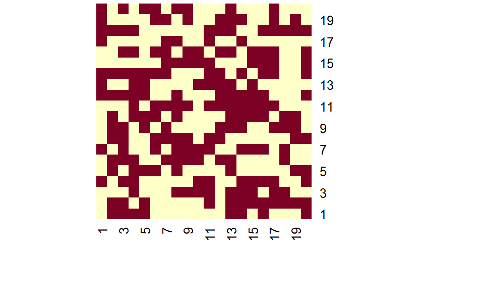

```r
sparse_mat <- sparse_matrix(20, density = 0.5)
heatmap(binarize_matrix(sparse_mat),Rowv = NA, Colv = NA, scale = "none")
```

```r
size = 20
str_var <- seq(0.01, 0.15, by = 0.005)
stable_probs_s <- numeric(length(str_var))
total <- 1000

for (i in seq_along(str_var)) {
  k <- str_var[i]
  count <- 0
  for (j in 1:total) {
    mati<- sparse_matrix(size, density = 0.5, sd = sqrt(k))

    if (check_eigenvalues(mati)) {
      count <- count + 1
    }
  }
  stable_probs_s[i] <- count/total
}
```

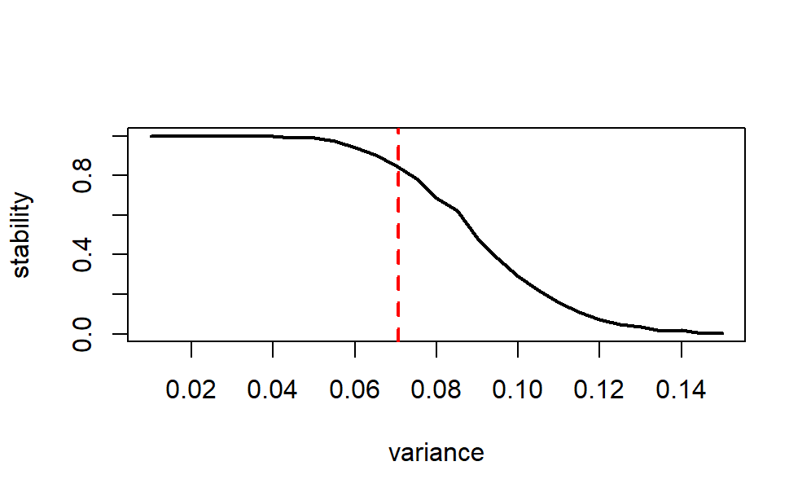

```r
plot(str_var, stable_probs_s, type = "l", lwd = 2,
     xlab = "variance", ylab = "stability",)
abline(v = sqrt(2)*1/20, col = "red",lwd = 2, lty = 2)
```

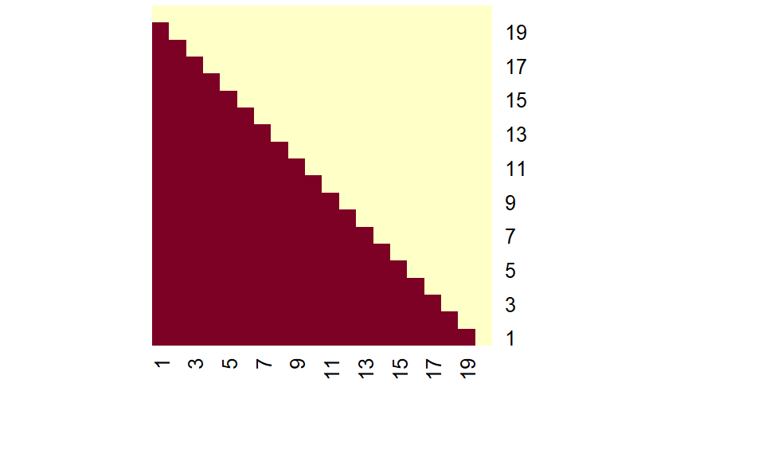

```r
nest_matrix <- function(size,
                                   dist_fun = rnorm, ...,
                                   symmetric = FALSE){
  mat <- matrix(dist_fun(size * size, ...),
                nrow = size, ncol = size)
  for (i in 1:size) {
    for (j in (size+1-i):size) {
      mat[i,j]<-0
    }
  }
  return(mat)
}
nest_mat <- nest_matrix(20, mean = 0)
heatmap(binarize_matrix(nest_mat,0.001),Rowv = NA, Colv = NA, scale = "none")
```

```r
stable_probs_n <- numeric(length(str_var))

for (i in seq_along(str_var)) {
  k <- str_var[i]
  count <- 0
  for (j in 1:total) {
    mati<- nest_matrix(size, sd = sqrt(k))

    if (check_eigenvalues(mati)) {
      count <- count + 1
    }
  }

  stable_probs_n[i] <- count/total
}
```

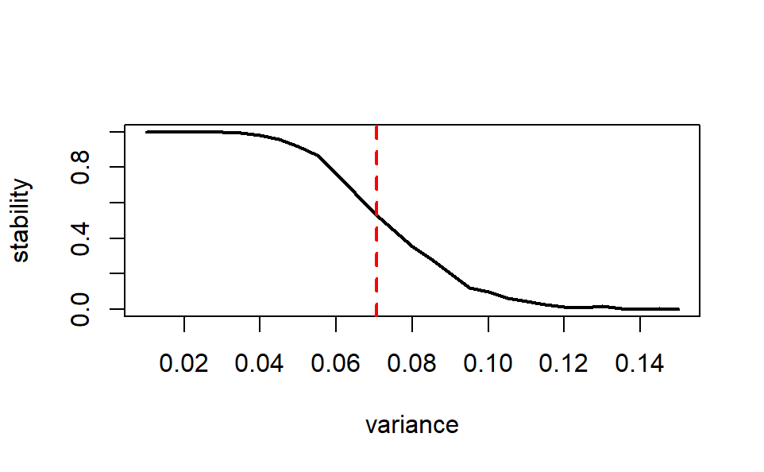

```r
plot(str_var, stable_probs_n, type = "l", lwd = 2,
     xlab = "variance", ylab = "stability",)
abline(v = sqrt(2)*1/20, col = "red",lwd = 2, lty = 2)
```

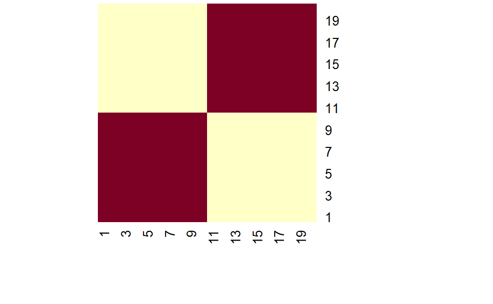

```r
modul_matrix <- function(size,
                        dist_fun = rnorm, ...,
                        symmetric = FALSE){
  mat <- matrix(dist_fun(size * size, ...),
                nrow = size,
                ncol = size)

  for (i in (size/2+1):size) {
    for (j in 1:(size/2)) {
      mat[i,j]<-0
    }
  }
  for (j in (size/2+1):size) {
    for (i in 1:(size/2)) {
      mat[i,j]<-0
    }
  }

  return(mat)
}
modul_mat <- modul_matrix(20)
heatmap(binarize_matrix(modul_mat),Rowv = NA, Colv = NA, scale = "none")
```

```r
stable_probs_m <- numeric(length(str_var))

for (i in seq_along(str_var)) {
  k <- str_var[i]
  count <- 0
  for (j in 1:total) {
    mat<- modul_matrix(size, sd = sqrt(k))

    if (check_eigenvalues(mat)) {
      count <- count + 1
    }
  }

  stable_probs_m[i] <- count/total
}
```

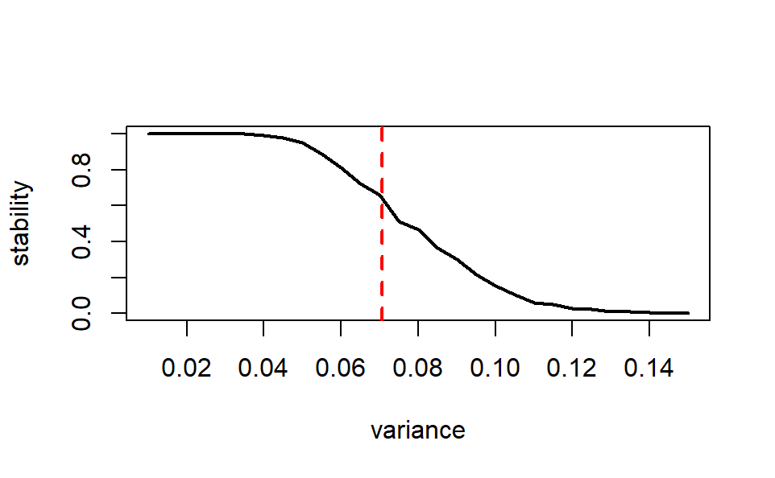

```r
plot(str_var, stable_probs_m, type = "l", lwd = 2,
     xlab = "variance", ylab = "stability",)
abline(v = sqrt(2)*1/20, col = "red",lwd = 2, lty = 2)
```

```r
plot(str_var, stable_probs_s, type = "l", lwd = 2,
     xlab = "sigma", ylab = "stability",)
lines(str_var, stable_probs_n, type="l", lwd = 2, col="darkgreen")
```

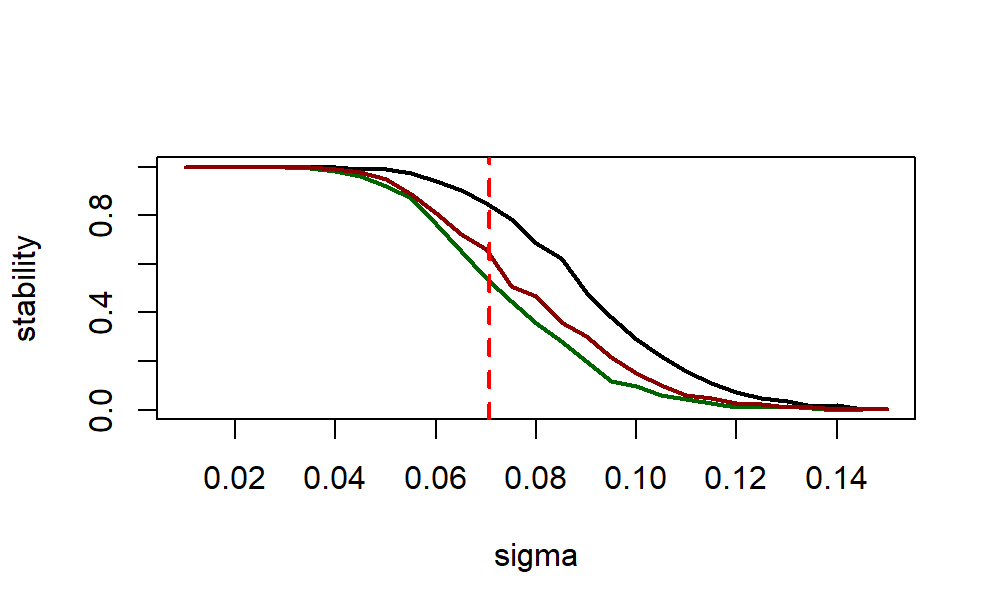

```r
lines(str_var, stable_probs_m, type="l", lwd = 2, col="darkred")


abline(v = sqrt(2)*1/20, col = "red",lwd = 2, lty = 2)
```

```r
compute_radius <- function(mat){
  eig_values <- eigen(mat, only.values = TRUE)$values

  mod_values <- Mod(eig_values)

  radius <- max(mod_values)
  return(radius)
}
```

```r
plot(str_var, radius_r, type = "l", lwd = 2,
     xlab = "sigma", ylab = "radius",)
lines(str_var, radius_n, type="l", lwd = 2, col="darkgreen")
```

[output not shown]

[figure not shown]

```r
lines(str_var, radius_m, type="l", lwd = 2, col="darkred")
```

```r
NA
NA
```